# Exploring the U.S. NOAA storm database

Himanshu Raj

9 January 2018

## Introduction

Storms and other severe weather events can cause both public health and economic problems for communities and municipalities. Many severe events can result in fatalities, injuries, and property damage, and preventing such outcomes to the extent possible is a key concern.

This project involves exploring the U.S. National Oceanic and Atmospheric Administration’s (NOAA) storm database. This database tracks characteristics of major storms and weather events in the United States, including when and where they occur, as well as estimates of any fatalities, injuries, and property damage.

## Data Processing

### About Data

The data for this assignment come in the form of a comma-separated-value file compressed via the bzip2 algorithm to reduce its size. You can download the file from the course web site.

The events in the database start in the year 1950 and end in November 2011. In the earlier years of the database there are generally fewer events recorded, most likely due to a lack of good records. More recent years should be considered more complete.

### Goal

1. Across the United States, which types of events (as indicated in the EVTYPE variable) are most harmful with respect to population health?
2. Across the United States, which types of events have the greatest economic consequences?

### Loading and viewing the data

```r
library(ggplot2)
library(plyr)
library(dplyr)
```

```r
setwd("D:/Test/Coursera/RepData_PeerAssessment2/RepData_PeerAssignment2")
stormData<- read.csv("repdata%2Fdata%2FStormData.csv.bz2", header = T, sep = ",")
head(stormData)
```

```
##   STATE__           BGN_DATE BGN_TIME TIME_ZONE COUNTY COUNTYNAME STATE
## 1       1  4/18/1950 0:00:00     0130       CST     97     MOBILE    AL
## 2       1  4/18/1950 0:00:00     0145       CST      3    BALDWIN    AL
## 3       1  2/20/1951 0:00:00     1600       CST     57    FAYETTE    AL
## 4       1   6/8/1951 0:00:00     0900       CST     89    MADISON    AL
## 5       1 11/15/1951 0:00:00     1500       CST     43    CULLMAN    AL
## 6       1 11/15/1951 0:00:00     2000       CST     77 LAUDERDALE    AL
##    EVTYPE BGN_RANGE BGN_AZI BGN_LOCATI END_DATE END_TIME COUNTY_END
## 1 TORNADO         0                                               0
## 2 TORNADO         0                                               0
## 3 TORNADO         0                                               0
## 4 TORNADO         0                                               0
## 5 TORNADO         0                                               0
## 6 TORNADO         0                                               0
##   COUNTYENDN END_RANGE END_AZI END_LOCATI LENGTH WIDTH F MAG FATALITIES
```

[output cut: 20 more lines]

### Calculating Fatalities

```r
aggDataFat<- aggregate(stormData$FATALITIES ~ stormData$EVTYPE, FUN=sum, na.rm=T)
aggDataFat<- aggDataFat[complete.cases(aggDataFat), ]
colnames(aggDataFat)<- c("Event", "Fatalities")
aggDataFat<- aggDataFat[order(aggDataFat$Fatalities, decreasing = T),]
```

### Calculating Injured

```r
aggDataInj<- aggregate(stormData$INJURIES ~ stormData$EVTYPE, FUN=sum, na.rm=T)
aggDataInj<- aggDataInj[complete.cases(aggDataInj), ]
colnames(aggDataInj)<- c("Event", "Injuries")
aggDataInj<- aggDataInj[order(aggDataInj$Injuries, decreasing = T),]
```

### Plotting Fatalities and Injuries

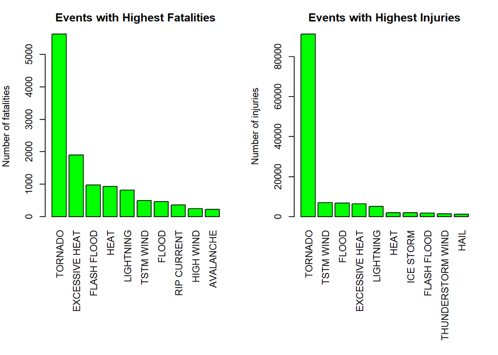

```r
aggDataFat<- aggDataFat[1:10, ]
aggDataInj<- aggDataInj[1:10, ]
par(mfrow = c(1, 2), mar = c(12, 4, 3, 2), mgp = c(3, 1, 0), cex = 0.8)
barplot(aggDataFat$Fatalities, las = 3, names.arg = aggDataFat$Event, main = "Events with Highest Fatalities",
        ylab = "Number of fatalities", col = "green")
barplot(aggDataInj$Injuries, las = 3, names.arg = aggDataInj$Event, main = "Events with Highest Injuries",
        ylab = "Number of injuries", col = "green")
```

## Finding which types of events have the greatest economic consequences

### Subsetting the Data

```r
newdata<- stormData[, c("COUNTYNAME", "STATE", "EVTYPE", "PROPDMG", "PROPDMGEXP", "CROPDMG", "CROPDMGEXP", "WFO", "LATITUDE")]
```

### Finding unique values of Exponential code

```r
unique(newdata$PROPDMGEXP)
```

```
##  [1] K M   B m + 0 5 6 ? 4 2 3 h 7 H - 1 8
## Levels:  - ? + 0 1 2 3 4 5 6 7 8 B h H K m M
```

### Substituting with the correct values to calculate the total

```r
newdata$PROPEXP[newdata$PROPDMGEXP == "K"] <- 1000
newdata$PROPEXP[newdata$PROPDMGEXP == "M"] <- 1e+06
newdata$PROPEXP[newdata$PROPDMGEXP == ""] <- 1
newdata$PROPEXP[newdata$PROPDMGEXP == "B"] <- 1e+09
newdata$PROPEXP[newdata$PROPDMGEXP == "m"] <- 1e+06
newdata$PROPEXP[newdata$PROPDMGEXP == "0"] <- 1
newdata$PROPEXP[newdata$PROPDMGEXP == "5"] <- 1e+05
newdata$PROPEXP[newdata$PROPDMGEXP == "6"] <- 1e+06
newdata$PROPEXP[newdata$PROPDMGEXP == "4"] <- 10000
newdata$PROPEXP[newdata$PROPDMGEXP == "2"] <- 100
newdata$PROPEXP[newdata$PROPDMGEXP == "3"] <- 1000
newdata$PROPEXP[newdata$PROPDMGEXP == "h"] <- 100
newdata$PROPEXP[newdata$PROPDMGEXP == "7"] <- 1e+07
newdata$PROPEXP[newdata$PROPDMGEXP == "H"] <- 100
newdata$PROPEXP[newdata$PROPDMGEXP == "1"] <- 10
newdata$PROPEXP[newdata$PROPDMGEXP == "8"] <- 1e+08
```

### Assigning ‘0’ to invalid exponent data

```r
newdata$PROPEXP[newdata$PROPDMGEXP == "+"] <- 0
newdata$PROPEXP[newdata$PROPDMGEXP == "-"] <- 0
newdata$PROPEXP[newdata$PROPDMGEXP == "?"] <- 0
```

### Calculating the property damage value

```r
newdata$PROPDMG_Total<- newdata$PROPEXP*newdata$PROPDMG
```

### calculcating the sum of total propert damage

```r
aggdata_PropDmg<- aggregate(newdata$PROPDMG_Total~newdata$EVTYPE, FUN = sum, na.rm=T)
names(aggdata_PropDmg)<- c("Event","TotalProp_Dmg")
aggdata_PropDmg<- aggdata_PropDmg[order(aggdata_PropDmg$TotalProp_Dmg, decreasing = T), ]
```

### Finding unique values of Exponential code for Crop Damage

```r
unique(newdata$CROPDMGEXP)
```

```
## [1]   M K m B ? 0 k 2
## Levels:  ? 0 2 B k K m M
```

### Substituting with the correct values to calculate the total

```r
newdata$CROPEXP[newdata$CROPDMGEXP == "M"] <- 1e+06
newdata$CROPEXP[newdata$CROPDMGEXP == "K"] <- 1000
newdata$CROPEXP[newdata$CROPDMGEXP == "m"] <- 1e+06
newdata$CROPEXP[newdata$CROPDMGEXP == "B"] <- 1e+09
newdata$CROPEXP[newdata$CROPDMGEXP == "0"] <- 1
newdata$CROPEXP[newdata$CROPDMGEXP == "k"] <- 1000
newdata$CROPEXP[newdata$CROPDMGEXP == "2"] <- 100
newdata$CROPEXP[newdata$CROPDMGEXP == ""] <- 1
```

### Assigning ‘0’ to invalid exponent data

```r
newdata$CROPEXP[newdata$CROPDMGEXP == "?"] <- 0
```

### Calculating the crop damage value

```r
newdata$CROPDMG_Total <- newdata$CROPDMG * newdata$CROPEXP
```

### Calculcating the sum of total crop damage

```r
aggdata_CropDmg<- aggregate(newdata$CROPDMG_Total~newdata$EVTYPE, FUN = sum, na.rm=T)
names(aggdata_CropDmg)<- c("Event","TotalCrop_Dmg")
aggdata_CropDmg<- aggdata_CropDmg[order(aggdata_CropDmg$TotalCrop_Dmg, decreasing = T), ]
```

### Plotting the Property Damage and Crop Damage

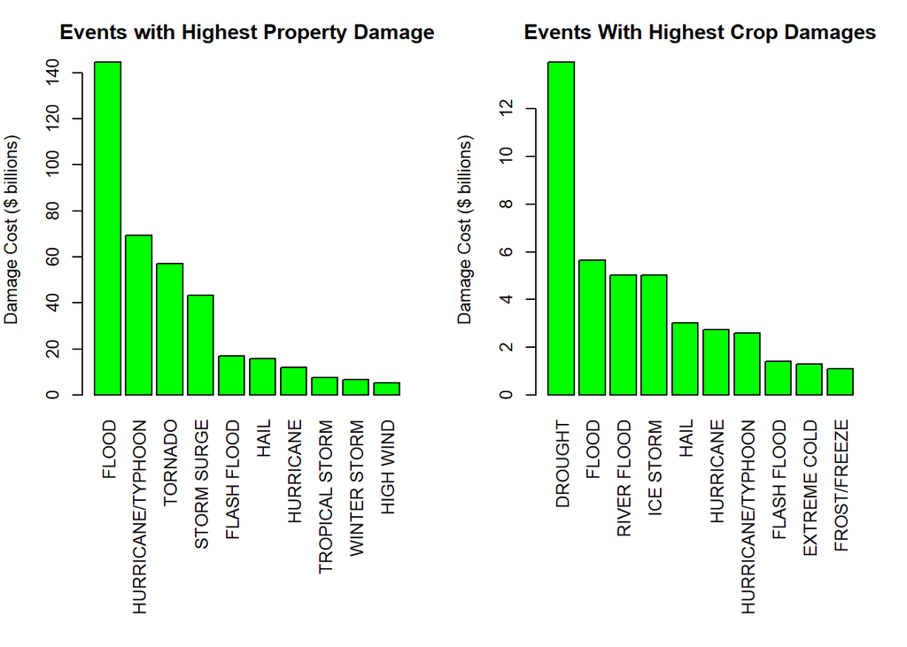

```r
aggdata_PropDmg<- aggdata_PropDmg[1:10,]
aggdata_PropDmg$TotalProp_Dmg<- aggdata_PropDmg$TotalProp_Dmg/(10^9)
aggdata_CropDmg<- aggdata_CropDmg[1:10,]
aggdata_CropDmg$TotalCrop_Dmg<- aggdata_CropDmg$TotalCrop_Dmg/(10^9)
par(mfrow = c(1, 2), mar = c(12, 4, 3, 2), mgp = c(3, 1, 0), cex = 0.8)
barplot(aggdata_PropDmg$TotalProp_Dmg, las = 3, names.arg = aggdata_PropDmg$Event, main = "Events with Highest Property Damage",
        ylab = "Damage Cost ($ billions)", col = "green")
barplot(aggdata_CropDmg$TotalCrop_Dmg, las = 3, names.arg = aggdata_CropDmg$Event, main = "Events With Highest Crop Damages",
        ylab = "Damage Cost ($ billions)", col = "green")
```